# Homework 03 Data Cleaning, Normal Distributions

Due by 11:59pm, Friday 9.26.25

S&DS 2300/5300/ENV 757

## Submission Details

**(1) More on List Manipulation** *(18 points - 3 points each)*.

(1.1) Make an object called `myList` that contains the following elements (in order):

- A matrix with the integers 1 through 36 that has six rows, filled by row
- A list that contains
  - A vector with the text “Pianoforte” and “Gerbera Daisy”
  - A vector with the integers 9 through 13
- The integers 1 through 10

You should be able to make this object in a single line of code.

*Use `[]`, `[[]]`, `[,]` notation to answer parts b) through f).*

(1.2) Make an object called `ans1` that is the third row of the matrix contained in `myList`.

(1.3) Make an object called `ans2` that is the sum of the 6th column of the matrix contained in `myList`.

(1.4) Make an object called `ans3` that is the sum of EACH column of the matrix contained in `myList` *(use the `apply()` function or check out `colSums()`)*.

(1.5) Make an object called `ans4` that is the single element of `myList` that you can play.

(1.6) Make an object called `ans5` that is the third element of the second element of the second element of `myList` converted to characters.

Get the results of each of your objects you created above (i.e. get them to show up in your knitted file by typing their names or putting the code line that creates each object in parentheses).

```r
# 1.1
myList <- list(matrix(1:36, nrow = 6, byrow = TRUE), list(c("Pianoforte", "Gerbera Daisy"), 9:13), 1:10)
myList
```

```
## [[1]]
##      [,1] [,2] [,3] [,4] [,5] [,6]
## [1,]    1    2    3    4    5    6
## [2,]    7    8    9   10   11   12
## [3,]   13   14   15   16   17   18
## [4,]   19   20   21   22   23   24
## [5,]   25   26   27   28   29   30
## [6,]   31   32   33   34   35   36
##
## [[2]]
## [[2]][[1]]
## [1] "Pianoforte"    "Gerbera Daisy"
##
## [[2]][[2]]
## [1]  9 10 11 12 13
##
##
## [[3]]
##  [1]  1  2  3  4  5  6  7  8  9 10
```

```r
# 1.2
ans1 <- myList[[1]][3, ]
ans1
```

```
## [1] 13 14 15 16 17 18
```

```r
# 1.3
ans2 <- sum(myList[[1]][, 6])
ans2
```

```
## [1] 126
```

```r
# 1.4
ans3 <- apply(myList[[1]], 2, sum)
ans3
```

```
## [1]  96 102 108 114 120 126
```

```r
# 1.5
ans4 <- myList[[2]][[1]][1]
ans4
```

```
## [1] "Pianoforte"
```

```r
# 1.6
ans5 <- as.character(myList[[2]][[2]][3])
ans5
```

```
## [1] "11"
```

**(2) Normal Quantile Plots and the Binomial Distribution** *(20 points, 3 points each, part (2.5) is 5 points)*.

You may recall from your Intro Statistics course that a binomial distribution looks like a normal distribution if np > 10 and n(1-p) > 10 (i.e. as long as the average number of successes and failures are both larger than 10). Recall that n is the number of trials, and p is the probability of success for each Bernoulli trial. *As an example, flip a coin 30 times, count the number of heads. n=30, p=.5, np = 15 > 10 and n(1-p) = 15 > 10, so the distribution should be approximately normal)*.

You are going to make six normal quantile plots that simulate 127 random observations from binomial distributions with p = 0.3 and various values of n.

(2.1) Install the `car` package. This will allow you use the `qqPlot()` function. Load this package.

(2.2) Make a vector called `vec` that is powers of 10 for powers 0 through 5. The one caveat is that you need to use the`**` operator which reads as ‘to the power of’ *(i.e. `2**3` is 8).* Show what is contained in `vec`.

(2.3) Use the `par()` function to set up your plot region to show 6 plots on a page. Go learn about the `mfrow` option in par to create a plot that was two rows and three columns.

(2.4) Use the `rbinom()` function to generate 6 random binomial observations, each with 17 trials, and with p=0.6. You may need to type `?rbinom` to get the syntax for this function (it is somewhat counterintuitive). Store the result in an object called `vec2` and show what is contained in `vec2`.

(2.5) Write a loop that repeatedly creates a normal quantile plot for 127 random samples each from a binomial distribution with p = 0.3 and n equal to the 6 values stored in `vec`. A few plot details: * Use the `qqPlot` function. * Make the graph points red solid dots (`pch = 19`). * Make the boundary lines blue (use `col.lines`) * Make a main graph title that pastes the text “127 Binomial Samples, N =” to the corresponding value from `vec`.

```r
# 2.1
# install.packages("car")
library(car)
# 2.2
vec <- sapply(0:5, function(x) 10^x)
vec
```

```
## [1] 1e+00 1e+01 1e+02 1e+03 1e+04 1e+05
```

```r
# 2.3
par(mfrow = c(2, 3))

# 2.4
vec2 <- rbinom(6, 17, 0.6)
vec2
```

```
## [1]  8 12 12  9  9 12
```

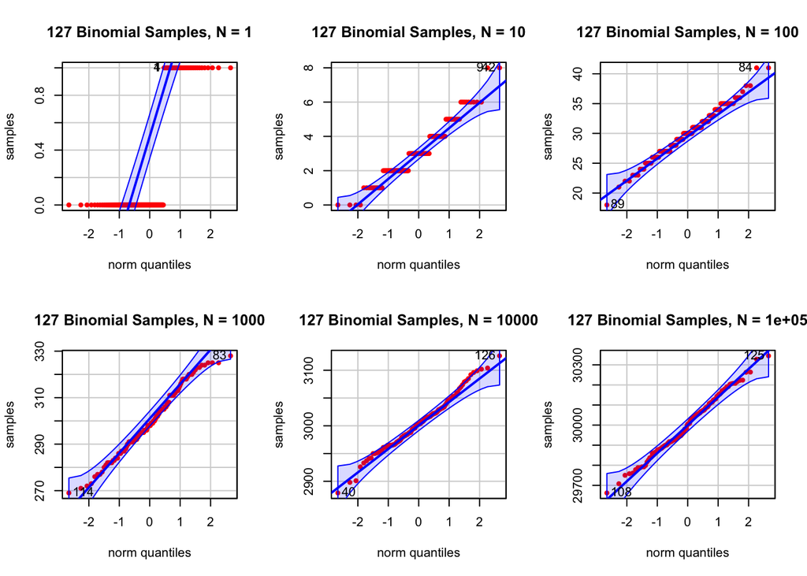

```r
# 2.5
for (n_val in vec){
  samples <- rbinom(127, n_val, 0.3)
  qqPlot(samples,
         pch = 19,
         col = "red",
         col.lines = "blue",
         main = paste("127 Binomial Samples, N =", n_val))
}
```

(2.6) Take a look at the normal quantile plots. For what value of n do the graphs seem to be approximately normally distributed? Is this consistent with what you expect? Write two complete sentences to answer these questions.

*The graphs seem to be approximately normally distributed at n values greater than or equal to 100. This is consistent with what I expect because the binominal distribution looks like a normal distribution when np > 10 and n(1-p) > 10, and in our case, these inequalities are true when n = 100.*

**(3) Favorite food and Data Cleaning** *(62 points. Parts 3.2 through 3.5, 2 pts each, other values listed below)*.

This is data generated by former students. I simply asked “What is your favorite food?”. You can get the data [HERE](https://raw.githubusercontent.com/jreuning/sds230_data/refs/heads/main/Food_230.csv).

Your goal is similar to what we did with the question “What animal would you like to be?” in Class 5: clean this variable, make a barplot, and discuss the results.

(3.1) *(1 pt)* Read in the data to a new object called `food`.

(3.2) Get a sense of the dataset - dimensions, variable names, look at the first few rows.

(3.3) Convert `food` to a single vector that is just the first column (literally, replace `food` with `food$Food`). if you need to, convert this value to character.

(3.4) Show the sorted unique values of `food`. Calculate how many unique values exist in `food`.

```r
# 3.1
food <- read.csv("https://raw.githubusercontent.com/jreuning/sds230_data/refs/heads/main/Food_230.csv")

# 3.2
dim(food)
```

```
## [1] 317   1
```

```r
names(food)
```

```
## [1] "Food"
```

```r
head(food)
```

```
##             Food
## 1  french fries.
## 2        Chicken
## 3 butter chicken
## 4         Ginger
## 5      Dal Bhaat
## 6      Thai food
```

```r
# 3.3
food <- food$Food

# 3.4
sort(unique(food))
```

```
##   [1] "Albanian Food "
##   [2] "all kinds of delicious food"
##   [3] "amaretto dark chocolate"
##   [4] "any type of cheese"
##   [5] "Arepa"
##   [6] "Artichoke"
##   [7] "Asian cuisine"
##   [8] "asian food"
##   [9] "Asian food"
##  [10] "Bagel"
##  [11] "baguettes"
##  [12] "Bananas"
##  [13] "Blue Point Oyster"
##  [14] "brazilian chorizo pizzas"
##  [15] "Brazilian food."
```

[output cut: 203 more lines]

```r
length(unique(food))
```

```
## [1] 218
```

(3.5) Write a couple of sentences about what data cleaning issues you notice amoung the unique values of `food`.

*I can see that there are a lot of repeat items due to different capitalization, details, etc. Some people also wrote their answers as sentences rather than a single noun, and some people described a food related to a culture while others specified which foods from the same culture.*

(3.6) Cleaning Part I *(8 pts)*: Clean the data using the following steps (in order):

- Convert data to lower case
- Find ” or ” and remove this and anything that follows.
- Find ” and ” and remove this and anything that follows.
- Find ” food” and remove this AND anything that follows.
- Find ” cuisine” and remove this AND anything that follows.
- Remove all special characters and punctuation - see class 6.
- Remove trailing spaces at the end of text

At each step, you’ll probably want to check what unique values of `food` are left to make sure your functions are working correctly. By the time you finish, you should have 156 unique levels.

Your final two lines of code should again show the sorted unique values of food and the current number of unique values.

```r
# Convert data to lower case
food <- tolower(food)
# unique(food)

# Find " or " and remove this and anything that follows.
food <- sub(" or .*", "", food)
# unique(food)

# Find " and " and remove this and anything that follows.
food <- sub(" and .*", "", food)
# unique(food)

# Find " food" and remove this AND anything that follows.
food <- sub(" food.*", "", food)
# unique(food)

# Find " cuisine" and remove this AND anything that follows.
food <- sub(" cuisine.*", "", food)
# unique(food)

# Remove all special characters and punctuation - see class 6.
food <- gsub("[^0-9A-Za-z/' ]", "'", food)
food <- gsub("'", "", food)
# unique(food)

# Remove trailing spaces at the end of text
food <- gsub("\\s$", "", food)

# Your final two lines of code should again show the sorted unique values of food and the current number of unique values.
sort(unique(food))
```

```
##   [1] "albanian"
##   [2] "all kinds of delicious"
##   [3] "amaretto dark chocolate"
##   [4] "any type of cheese"
##   [5] "arepa"
##   [6] "artichoke"
##   [7] "asian"
##   [8] "bagel"
##   [9] "baguettes"
##  [10] "bananas"
##  [11] "blue point oyster"
##  [12] "brazilian"
##  [13] "brazilian chorizo pizzas"
##  [14] "bread"
##  [15] "burgers"
```

[output cut: 141 more lines]

```r
length(unique(food))
```

```
## [1] 156
```

(3.7) Cleaning Part II *(10 pts)*: A few quick random cleaning items:

Clean up the following types of food (in order) - one line of code per type of food. In each case, deal with misspellings, modifiers (“shrimp curry” vs just “curry”), two words (‘hot pot’ instead of ‘hotpot’), plurals, etc.

- hotpot
- curry
- lasagna
- noodles
- cookies
- chocolate
- cheese
- steak
- sushi
- fries (french, cajun, five guys’ should all be ‘fries’)
- ramen
- tofu
- burgers (of any kind)
- soup
- anything containing ‘delicious’ just call ‘delicious’

When you’re finished, you should have 130 unique values.

Your final two lines of code should again show the sorted unique values of food and the current number of unique values.

```r
food <- gsub("hot ?pot|.*hotpot.*", "hotpot", food)
food <- gsub(".*curry.*", "curry", food)
food <- gsub("lasagne", "lasagna", food)
food <- gsub(".*noodle.*", "noodles", food)
food <- gsub(".*cookies.*", "cookies", food)
food <- gsub(".*chocolate.*", "chocolate", food)
# I included cheez its when making the cheese type of food because I was hitting 131 unique values at the end and cheez itz was the only entry that I thought could be substituted given the instructions
food <- gsub(".*chee.*", "cheese", food)
food <- gsub(".*steak.*", "steak", food)
food <- gsub(".*sushi.*", "sushi", food)
food <- gsub(".*fries.*", "fries", food)
food <- gsub(".*ramen.*", "ramen", food)
food <- gsub(".*tofu.*", "tofu", food)
food <- gsub(".*burger.*", "burgers", food)
food <- gsub(".*soup.*", "soup", food)
food <- gsub(".*delicious.*", "delicious", food)

sort(unique(food))
```

```
##   [1] "albanian"
##   [2] "arepa"
##   [3] "artichoke"
##   [4] "asian"
##   [5] "bagel"
##   [6] "baguettes"
##   [7] "bananas"
##   [8] "blue point oyster"
##   [9] "brazilian"
##  [10] "brazilian chorizo pizzas"
##  [11] "bread"
##  [12] "burgers"
##  [13] "burritos"
##  [14] "butter chicken"
##  [15] "cake"
```

[output cut: 115 more lines]

```r
length(unique(food))
```

```
## [1] 130
```

(3.8) Cleaning Part III *(8 pts)*: Cleaning types of cuisine.

Clean up the following types of cuisine (in order) - in this case, you’ll want to make a vector called `searchvec` that contains the types of cuisine. Then create a loop following the example in Class 5 to replace all the modifiers for each cuisine type so that you ultimately end up with cleaned up versions of each cuisine type. Use not more than 5 lines of code.

The cuisine types (in order) are * asian * chinese * vietnamese * italian * indian * thai * mexican * brazilian * korean

(there are other types of cuisine, but they don’t require cleaning).

When you’re finished, you should have 120 unique values.

Your final two lines of code should again show the sorted unique values of food and the current number of unique values.

```r
searchvec <- c("asian", "chinese", "vietnamese", "italian", "indian", "thai", "mexican", "brazilian", "korean")
for (i in 1:length(searchvec)){
  food <- gsub(paste0(".*", searchvec[i], ".*"), searchvec[i], food)
}

sort(unique(food))
```

```
##   [1] "albanian"                     "arepa"
##   [3] "artichoke"                    "asian"
##   [5] "bagel"                        "baguettes"
##   [7] "bananas"                      "blue point oyster"
##   [9] "brazilian"                    "bread"
##  [11] "burgers"                      "burritos"
##  [13] "butter chicken"               "cake"
##  [15] "ceviche"                      "cheese"
##  [17] "chicken"                      "chicken malai kabab"
##  [19] "chicken parmesan"             "chicken tenders"
##  [21] "chicken tikka"                "chicken tikka masala"
##  [23] "chicken wings"                "chinese"
##  [25] "chipotle"                     "chocolate"
##  [27] "cinnamon rolls"               "comfort"
##  [29] "cookies"                      "corn"
```

[output cut: 45 more lines]

```r
length(unique(food))
```

```
## [1] 120
```

(3.9) *(15 pts)* Following the example from Class 05, display a dataframe of the sorted tabular results of `food` to see how many individuals prefer each kind of food.

From here on, the decisions of how to clean and combine categories are yours! Any food that currently has a count of 3 or more should remain (you can add to these categories - for example, you could add ‘lasagna’ to ‘italian’ or to ‘pasta’). All other levels should be recoded or incorporated into a ‘miscellaneous’ food category. Points awarded based on thoughtfulness, effort, and quality/preciseness of your code.

Include your code below, and add comments where appropriate to describe the choices you make. You should have no more than 40 levels by the time you finish.

Display a dataframe of the sorted tabular results of `food` to see how many individuals prefer each kind of food AGAIN after you’ve finished your coding.

```r
table1 <- data.frame(sort(table(food), decreasing = T))
table1
```

```
##                             food Freq
## 1                          sushi   24
## 2                          pizza   17
## 3                         korean   14
## 4                           thai   14
## 5                        chinese   13
## 6                      ice cream   10
## 7                        mexican   10
## 8                         indian    9
## 9                        italian    9
## 10                         ramen    9
## 11                       noodles    8
## 12                         pasta    8
## 13                         steak    8
## 14                        cheese    6
```

[output cut: 106 more lines]

```r
# I saw that a lot of foods have "chicken" in them, so I wanted to generalize them to chicken
food <- gsub(".*chicken.*", "chicken", food)

# For these, I combined singular dishes into broader categories or categories that already existed (such as cuisines, food types, etc.)
mapping <- list(
  fruit = c("strawberries", "bananas", "dried mangos", "mango", "nectarines", "sundried tomatoes", "fruits"),
  dessert = c("cookies", "cake", "cinnamon rolls", "donuts"),
  mexican = c("burritos", "guacamole", "ceviche", "empanadas", "enchiladas", "fish tacos", "chipotle",
              "flautas", "platanos"),
  indian = c("palak paneer", "shahi paneer"),
  brazilian = c("farofa"),
  curry = c("curries of all sorts"),
  asian = c("tofu", "vietnamese", "dal bhaat", "dumplings", "fried rice", "hibachi", "indonesian",
            "poke bowl", "postickers"),
  seafood = c("salmon", "blue point oyster", "fish", "fried fish"),
  bread = c("bagel", "baguettes"),
  italian = c("gnocchi", "spaghetti"),
  pizza = c("good pizza"),
  american = c("hot dog", "mac", "macaroni", "patty melt", "ribs")
)

for (category in names(mapping)) {
  food[food %in% mapping[[category]]] <- category
}

# At this point, I couldn't find any more significant groupings/combinations, so I decided that any remaining entries that have a count of < 3 should be put into the miscellaneous category
food_counts <- table(food)
miscellaneous_foods <- names(food_counts[food_counts < 3])
food[food %in% miscellaneous_foods] <- "miscellaneous"

table2 <- data.frame(sort(table(food), decreasing = T))
table2
```

```
##             food Freq
## 1  miscellaneous   31
## 2          sushi   24
## 3        mexican   21
## 4          pizza   18
## 5          asian   16
## 6        chicken   15
## 7         korean   14
## 8           thai   14
## 9        chinese   13
## 10         fruit   11
## 11        indian   11
## 12       italian   11
## 13     ice cream   10
## 14         ramen    9
```

[output cut: 20 more lines]

(3.10) *(8 pts)* Final steps and a plot: You’ll want to CAREFULLY follow the example in the code at the end of Class 05.

- Use the `toTitleCase()` function from the package `tools` to convert food to title case.
- Make an object called `finaltab` that is a table of your final vector `food`.
- Calculate percents, rounded to the nearest integer, for each food type. Save this as an object called `percents`.
- Change the names of `finaltab` to include a space and then the percents followed by a “%” in curved parentheses.
- Make a horizontal barplot of your final plot. Choose a nice bar color, adjust the left margins as necessary, give a main title and label the horizontal axis.

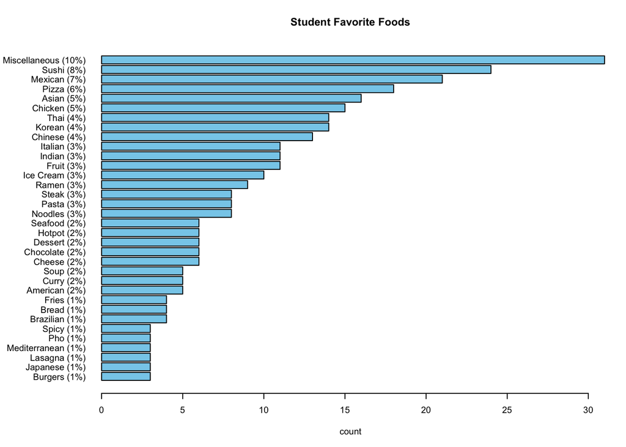

```r
library(tools)
food1 <- toTitleCase(food)
finaltab <- table(food1)
percents <- round(finaltab/sum(finaltab)*100, 0)
names(finaltab) <- paste0(names(finaltab)," (", percents, "%)")
par(mar = c(5, 9, 4, 2), cex = .6)
barplot(sort(finaltab), horiz = T, las = 1, col = "skyblue", main = "Student Favorite Foods", xlab = "count")
```

(3.11) *(3 pts)* In no more than three sentences, discuss your process and results. Be sure to mention how many unique values of ‘food’ you started and ended with. Any surprises?

*The workflow generally consisted of making everything the same capitalization (lowercase), simplifying some responses to more basic words (removing or, and, food, etc.), eliminating special characters, punctuation, and spaces, fixing misspellings, and combining similar categories. We initially started with 218 unique values of ‘food’, and we ended up narrowing it down to 34. I don’t think there’s anything too surprising, as the miscellaneous category was able to capture a lot of the unique values that didn’t end up in other categories.*

(4.1) Pseudocode.

You want to understand how to better promote tourism in New Haven and coastal Connecticut. A company collected open-ended survey responses to the question: “What is the main reason you would visit this area?” Each row is one person’s answer. The responses are messy: inconsistent capitalization, extra punctuation, multiple-word answers (“the beach!!!”), and people mixing categories (e.g., “pizza or seafood”). You want to:

1. Clean the responses so categories are consistent (lower case, remove punctuation, trim spaces)
2. Group answers into broader themes (e.g., pizza → food, museums → culture, beach → outdoor recreation)
3. Summarize the cleaned results into counts and percentages.
4. Visualize the final categories in a clear barplot.

Write pseudocode describing the steps you would take. Don’t write any R code, but you’re welcome to mention functions you would use.

*i) Clean the responses so categories are consistent (lower case, remove punctuation, trim spaces)* - *Convert all data to lowercase using tolower()* - *Split responses that include “and” or “or” into individual entries* - *For example, splitting “pizza or seafood” into “pizza” and “seafood”* - *Remove all special characters and punctuation* - *Do this by subbing out [^0-9A-Za-z/’ ] with “’” and then subbing out “’” with ““ *-* Trim spaces using trimws() *-* At this point, I would check for and remove misspellings and excess words (such as adjectives or words like”the”)*

*ii) Group answers into broader themes (e.g., pizza → food, museums → culture, beach → outdoor recreation)* - *Depending on the dataset, if a lot of people had specific types of pizza listed, I would make a group for pizza. Otherwise, I would include pizza and all other food items in a food category.* - *I think I would make a category for Yale and put any Yale events or landmarks in there.* - *I would make an outdoor recreation category that would include items like beach, trail, camp, etc.* - *Depending on the size of the dataset and the count distribution, I may want to make a miscellaneous category*

*iii) Summarize the cleaned results into counts and percentages.* - *Use data.frame(sort(table(new_haven), decreasing = T)) to show the remaining unique values and associated counts* - *Make the dataset into a table and make a percents variable and round to the first decimal place*

*iv) Visualize the final categories in a clear barplot.* - *Make a horizontal bar plot, making sure to have the labels on the y axis include the unique values along with the respective percent values, adjust margin sizes to make sure nothing is cut off, and have an appropriate color and title.*